# Week 5 Homework: Tidying Data

Aaron Grzasko

October 2, 2016

## Assignment Overview

The primary purpose of this exercise is to gain experience manipulating untidy data. We will use two powerful R packages–tidyr and dplyr–to wrangle a small albeit messy data set into tidy form.

According to Hadley Wickham–see *Tidy Data R Vignette*–tidy data conform to three principles:

- Variables are stored in separate columns
- Observations are stored in separate rows
- Each observational unit forms a table

Once we have tidied our data, we will perform basic graphical and statistical analysis.

## Libraries

```r
# install.packages(c("tidyr","dplyr"))
library(tidyr)
library(dplyr)
```

## Data

In this assignment, we review flight delay data for two airline carriers and five separate cities–refer to the [assignment instructions](https://bbhosted.cuny.edu/bbcswebdav/pid-25842532-dt-content-rid-119781391_1/xid-119781391_1) for more details.

This data was inputted manually in a .csv file and saved to a [Github repository](https://github.com/spitakiss/Data607_HW5/blob/master/flight_info.csv).

Let’s load the csv file into the R environment and view its contents:

```r
myurl <- "https://raw.githubusercontent.com/spitakiss/Data607_HW5/master/flight_info.csv"
flight <- read.csv(myurl, header = TRUE, stringsAsFactors = FALSE)
flight
```

```
        X     X.1 Los.Angeles Phoenix San.Diego San.Francisco Seattle
1  ALASKA on time         497     221       212           503    1841
2         delayed          62      12        20           102     305
3                          NA      NA        NA            NA      NA
4 AM WEST on time         694    4840       383           320     201
5         delayed         117     415        65           129      61
```

The current `flight` data frame is in a messy, wide format and will require multiple transforms to produce an object in tidy form.

## Tidy Operations

In transforming the raw `flight` object, we made the following assumptions:

- The flight statuses “on time” and “delayed” are separate variables and should be stored in separate columns.
- The various city columns in the raw data set belong to a master *city* variable and should be stored in a single column.
- An observation is defined by flight metrics for a specific airline and city combination.

```r
flight <-   flight %>%
                #1
                rename(airline = X, status = X.1) %>%  #1
                #2
                filter(status != "") %>%
                # 3
                mutate(
                    airline  = ifelse(airline == "", lag(airline),airline),
                    status = ifelse(status == "on time", "on_time", status)
                    ) %>%
                # 4
                gather("city", "num_flights", Los.Angeles:Seattle) %>%
                # 5
                spread(status, num_flights) %>%
                # 6
                mutate(
                    ttl_flights = delayed + on_time,
                    on_time_per = round(on_time / ttl_flights,4),
                    delay_per = round(delayed / ttl_flights,4)
                )

flight
```

```
   airline          city delayed on_time ttl_flights on_time_per delay_per
1   ALASKA   Los.Angeles      62     497         559      0.8891    0.1109
2   ALASKA       Phoenix      12     221         233      0.9485    0.0515
3   ALASKA     San.Diego      20     212         232      0.9138    0.0862
4   ALASKA San.Francisco     102     503         605      0.8314    0.1686
5   ALASKA       Seattle     305    1841        2146      0.8579    0.1421
6  AM WEST   Los.Angeles     117     694         811      0.8557    0.1443
7  AM WEST       Phoenix     415    4840        5255      0.9210    0.0790
8  AM WEST     San.Diego      65     383         448      0.8549    0.1451
9  AM WEST San.Francisco     129     320         449      0.7127    0.2873
10 AM WEST       Seattle      61     201         262      0.7672    0.2328
```

## Graphical and Tabular Summaries

**By City**  
Below we summarize the proportion of delayed flights by city for each airline, with output in both tabular and bar plot formats:

```r
flight.redux <- flight %>%
                    select(c(airline,city, delay_per)) %>%
                    spread(city, delay_per) %>%
                    select(Los.Angeles:Seattle) %>%
                    as.matrix()
rownames(flight.redux) <- unique(flight$airline)

flight.redux
```

```
        Los.Angeles Phoenix San.Diego San.Francisco Seattle
ALASKA       0.1109  0.0515    0.0862        0.1686  0.1421
AM WEST      0.1443  0.0790    0.1451        0.2873  0.2328
```

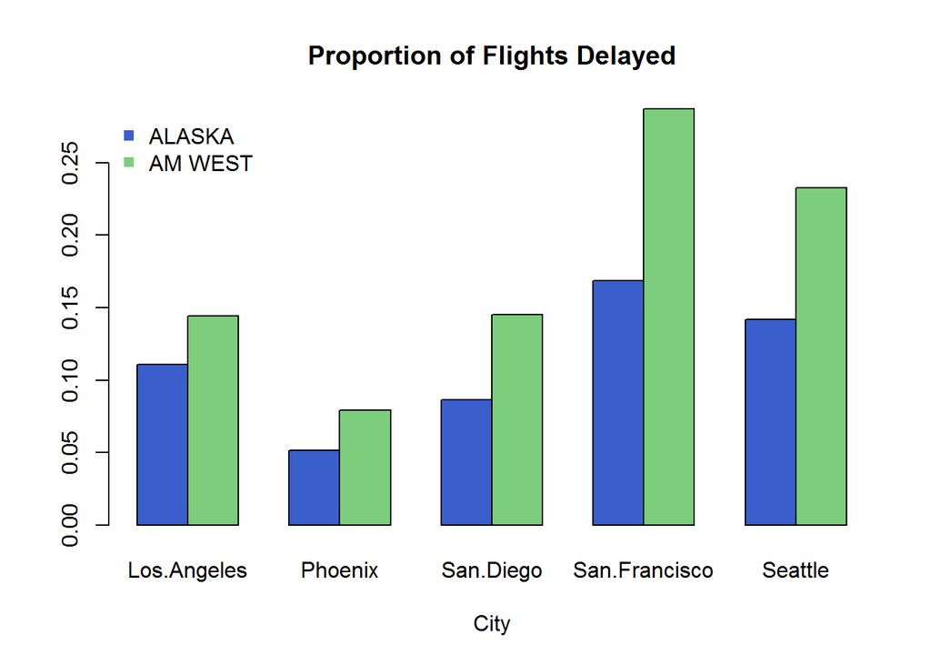

```r
barplot(flight.redux, beside = TRUE, main = "Proportion of Flights Delayed", xlab = "City", col=c("royalblue3","palegreen3"))
legend("topleft", rownames(flight.redux), pch = 15, bty = 'n', col = c("royalblue3","palegreen3"))
```

Interestingly enough, Alaska Airlines has a lower proportion of flight delays than AM West for each of the five observed cities.

**In Aggregate**  
Now, let’s produce a summary table and bar plot by carrier for all cities combined:

```r
flight_all_city <- flight %>%
                    group_by(airline) %>%
                    summarise(delay_prop = sum(delayed)/sum(ttl_flights)) %>%
                    select(delay_prop) %>%
                    as.matrix()

rownames(flight_all_city) <- unique(flight$airline)

flight_all_city
```

```
        delay_prop
ALASKA   0.1327152
AM WEST  0.1089273
```

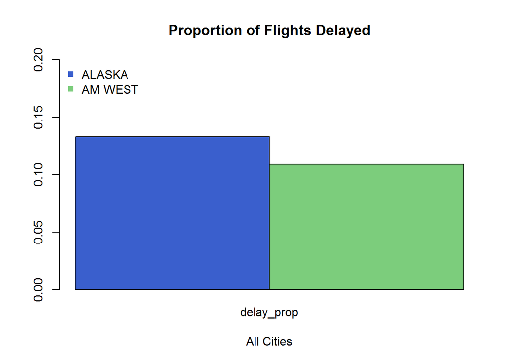

```r
barplot(flight_all_city, beside = TRUE, main = "Proportion of Flights Delayed", xlab = "All Cities", col=c("royalblue3","palegreen3"), ylim = c(0,0.2))

legend("topleft", rownames(flight_all_city), pch = 15, bty = 'n', col = c("royalblue3","palegreen3"))
```

Surprisingly, the flight data–when aggregated together–reveal a striking pattern reversal: AM West’s total flight delay percentage is lower than the corresponding percentage for Alaska!

These counter intuitive results are common to the world of statisticians. In fact, this phenomenon even has a name: [Simpson’s paradox](https://en.wikipedia.org/wiki/Simpson%27s_paradox).

## Statistical Analysis

**By City**  
As noted previously, the proportion of delayed flights for Alaska airlines is lower than AM West for each of the five cities in the data set. Let’s now use the function `prop.text()` to determine if the calculated difference in proportions is statistically meaningful at the 5% level of significance.

```r
for (i in unique(flight$city)){
    flight_sub <- filter(flight, city == i)
    delay_AM <- sum(select(filter(flight_sub, airline == 'AM WEST'),delayed))
    delay_AK <- sum(select(filter(flight_sub, airline =='ALASKA'), delayed))
    ttl_AM <- sum(select(filter(flight_sub, airline == 'AM WEST'),ttl_flights))
    ttl_AK <- sum(select(filter(flight_sub, airline == 'ALASKA'),ttl_flights))
    print("--------------------------------------------------------------------")
    cat("Prop test for:", i)
    print(prop.test(c(delay_AM,delay_AK), c(ttl_AM,ttl_AK)))
}
```

```
[1] "--------------------------------------------------------------------"
Prop test for: Los.Angeles
    2-sample test for equality of proportions with continuity
    correction

data:  c(delay_AM, delay_AK) out of c(ttl_AM, ttl_AK)
X-squared = 2.954, df = 1, p-value = 0.08566
alternative hypothesis: two.sided
95 percent confidence interval:
 -0.003687491  0.070395480
sample estimates:
   prop 1    prop 2
0.1442663 0.1109123

[1] "--------------------------------------------------------------------"
Prop test for: Phoenix
    2-sample test for equality of proportions with continuity
    correction

data:  c(delay_AM, delay_AK) out of c(ttl_AM, ttl_AK)
X-squared = 1.9792, df = 1, p-value = 0.1595
alternative hypothesis: two.sided
95 percent confidence interval:
 -0.004071878  0.059012400
sample estimates:
    prop 1     prop 2
0.07897241 0.05150215

[1] "--------------------------------------------------------------------"
Prop test for: San.Diego
    2-sample test for equality of proportions with continuity
    correction

data:  c(delay_AM, delay_AK) out of c(ttl_AM, ttl_AK)
X-squared = 4.3218, df = 1, p-value = 0.03763
alternative hypothesis: two.sided
95 percent confidence interval:
 0.006949539 0.110815239
sample estimates:
   prop 1    prop 2
```

[output cut: 14 more lines]

```
0.2873051 0.1685950

[1] "--------------------------------------------------------------------"
Prop test for: Seattle
    2-sample test for equality of proportions with continuity
    correction

data:  c(delay_AM, delay_AK) out of c(ttl_AM, ttl_AK)
X-squared = 14.207, df = 1, p-value = 0.0001637
alternative hypothesis: two.sided
95 percent confidence interval:
 0.03529326 0.14610583
sample estimates:
   prop 1    prop 2
0.2328244 0.1421249
```

Using a 5% level of significance, we reject the null hypothesis of equal delay proportions for the following cities:

- San Diego
- San Francisco
- Seattle

We fail to reject the null hypothesis for the following cities:

- Los Angeles
- Phoenix

**In Aggregate**  
Finally, let’s repeat the proportions test for the aggregated flight data:

```r
flight_all_city2 <- flight %>%
                    group_by(airline) %>%
                    summarise(
                        delayed = sum(delayed),
                        ttl_flights = sum(ttl_flights)
                        )

delay_AM2 <- sum(select(filter(flight_all_city2, airline == 'AM WEST'),delayed))
delay_AK2 <- sum(select(filter(flight_all_city2, airline =='ALASKA'), delayed))
ttl_AM2 <- sum(select(filter(flight_all_city2, airline == 'AM WEST'),ttl_flights))
ttl_AK2 <- sum(select(filter(flight_all_city2, airline == 'ALASKA'),ttl_flights))

print(prop.test(c(delay_AM2,delay_AK2), c(ttl_AM2,ttl_AK2)))
```

```
    2-sample test for equality of proportions with continuity
    correction

data:  c(delay_AM2, delay_AK2) out of c(ttl_AM2, ttl_AK2)
X-squared = 13.343, df = 1, p-value = 0.0002594
alternative hypothesis: two.sided
95 percent confidence interval:
 -0.03697936 -0.01059643
sample estimates:
   prop 1    prop 2
0.1089273 0.1327152
```

At the 5% level of significance, we reject the null hypothesis that the difference in proportions is zero.